# IODS course project

Once we observe the effects of **gender** and **age**, we can continue to evaluate the correlation between the learning types and the points of the examination. This can be done from the figure above or by plotting each scatter plot with their linear models separately. I always like to *double click* into each correlation, so here is a code for that.

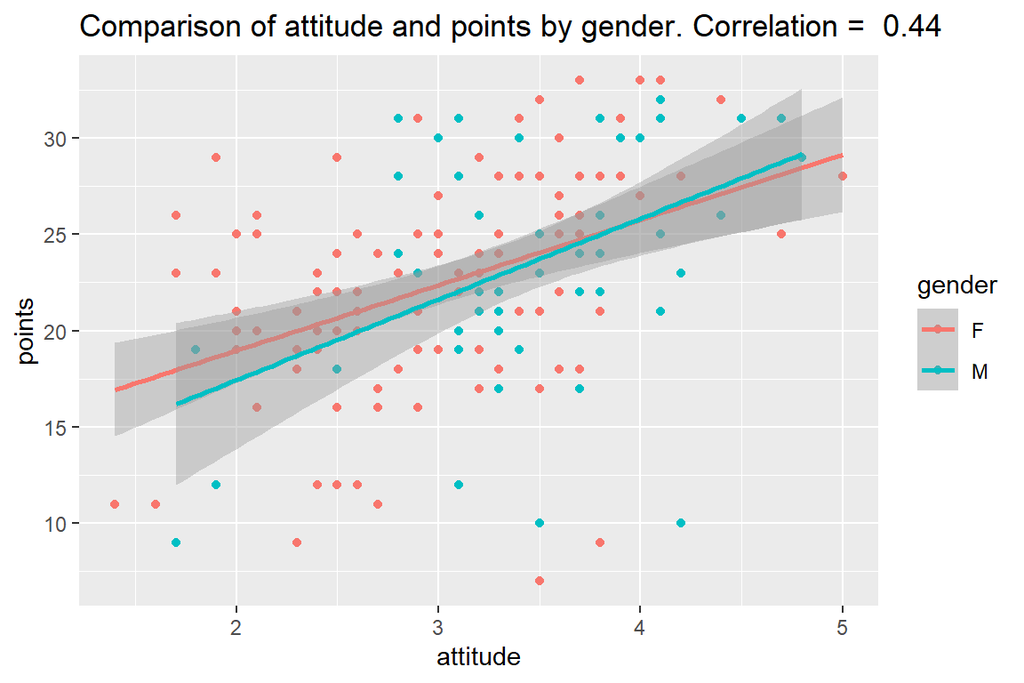

```r
# Attitude vs points
cor <- signif(cor(learning2014$attitude,learning2014$points),2) #calculate the correlation between the two variables
ggplot(learning2014, aes(x = attitude, y = points, col = gender)) + # Plot the variables stratified by gender
  geom_point() +
  geom_smooth(method ="lm", formula = 'y ~ x') + # Include the linear model
  ggtitle(paste("Comparison of attitude and points by gender. Correlation = ", cor)) # Create a title including the correlation coefficient
```

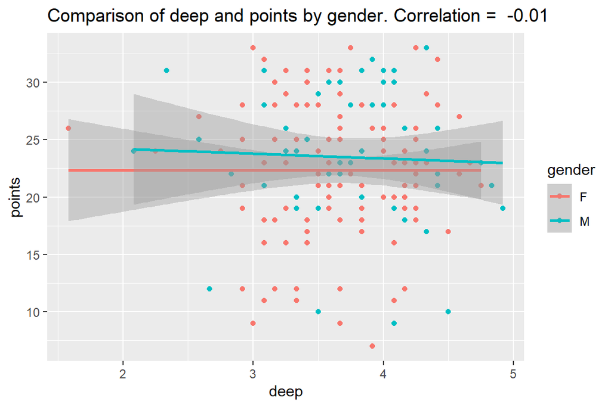

```r
# Deep vs points
cor <- signif(cor(learning2014$deep,learning2014$points),2)
ggplot(learning2014, aes(x = deep, y = points, col = gender)) +
  geom_point() +
  geom_smooth(method ="lm", formula = 'y ~ x') +
  ggtitle(paste("Comparison of deep and points by gender. Correlation = ", cor))
```

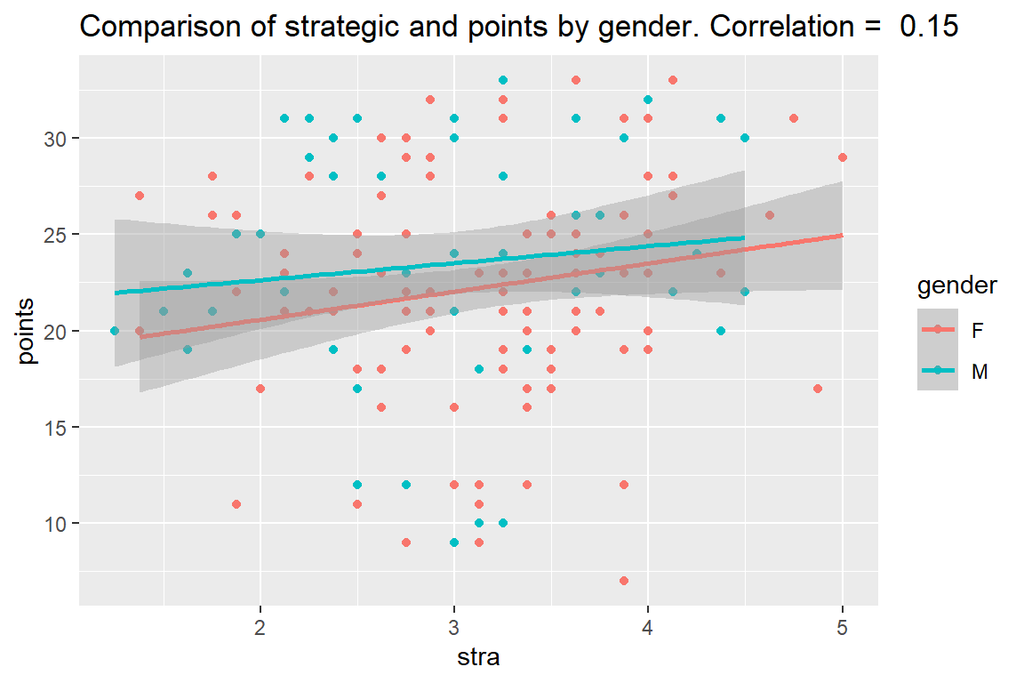

```r
# Strategic vs points
cor <- signif(cor(learning2014$stra,learning2014$points),2)
ggplot(learning2014, aes(x = stra, y = points, col = gender)) +
  geom_point() +
  geom_smooth(method ="lm", formula = 'y ~ x') +
  ggtitle(paste("Comparison of strategic and points by gender. Correlation = ", cor))
```

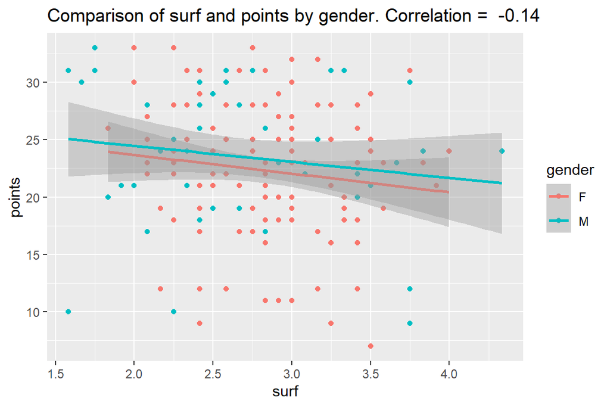

```r
# Surface vs points
cor <- signif(cor(learning2014$surf,learning2014$points),2)
ggplot(learning2014, aes(x = surf, y = points, col = gender)) +
  geom_point() +
  geom_smooth(method ="lm", formula = 'y ~ x') +
  ggtitle(paste("Comparison of surf and points by gender. Correlation = ", cor))
```

From these plots we can conclude:

- There is no significant correlation between **points** and **deep** learning for either male or female subjects.
- There is a higher correlation between **points** and **attitude** than any other of the learning types for both male and female subjects.
- Even when not as big as correlation between **points** and **attitude**, **strategic** and *surface** learning should be evaluated by multiple linear regression analysis to be excluded.

We start by including the three variables of interest into the multiple linear model and looking at the ANOVA presented by the *summary()* function.

```r
my_model <- lm(points ~ attitude + stra + surf, data = learning2014) # Create the model

summary(my_model) # Print the summary of results
```

```
##
## Call:
## lm(formula = points ~ attitude + stra + surf, data = learning2014)
##
## Residuals:
##      Min       1Q   Median       3Q      Max
## -17.1550  -3.4346   0.5156   3.6401  10.8952
##
## Coefficients:
##             Estimate Std. Error t value Pr(>|t|)
## (Intercept)  11.0171     3.6837   2.991  0.00322 **
## attitude      3.3952     0.5741   5.913 1.93e-08 ***
## stra          0.8531     0.5416   1.575  0.11716
## surf         -0.5861     0.8014  -0.731  0.46563
## ---
## Signif. codes:  0 '***' 0.001 '**' 0.01 '*' 0.05 '.' 0.1 ' ' 1
##
## Residual standard error: 5.296 on 162 degrees of freedom
## Multiple R-squared:  0.2074, Adjusted R-squared:  0.1927
## F-statistic: 14.13 on 3 and 162 DF,  p-value: 3.156e-08
```

First thing that jumps to view is the t statistic and its associated p-values. Both the intercept and the **attitude** coefficient give significant values (<0.05), while the rest remain non-significant. The p-value of the t statistic tells us the probability that the variation in the target variable being explained by the explanatory variable is happening by chance (due to standard error). When this probability is under our significance level, usually 0.05, we consider that the coefficient of our explanatory variable significantly explains the variation in the target variable. Therefore, we tentatively conclude that at least the **attitude** has a significant relationship with **point**.

Then, we observe the F-statistic and its associated p-value. The F-statistic tests the regression as a whole, which avoids the problems of p-values in multiple testing (which I think will be covered later in the course). Therefore, we also expect it to have a significant (<0.05) value, which it does! This means that at least one of the explanatory variables is causing this model to explain the variation in the target variable better than the Null distribution (all coefficients equal to zero).

Lastly, we look at the multiple R-squared. This tells us how much of the variation in our target variable is explained by the model instead of the error. We can see that 20.7% of the variation is explained by our explanatory variables. This is low, but we still have work to do.

When working with multiple linear regressions, you want to remove/add one explanatory variable at a time. Here we will take away the highest p-value of the t statistic since this tells us it is the explanatory variable that least explains our target variable’s variation. The chosen one is … **surface**.

We will now run the model again.

```r
my_model2 <- lm(points ~ attitude + stra, data = learning2014)

summary(my_model2)
```

```
##
## Call:
## lm(formula = points ~ attitude + stra, data = learning2014)
##
## Residuals:
##      Min       1Q   Median       3Q      Max
## -17.6436  -3.3113   0.5575   3.7928  10.9295
##
## Coefficients:
##             Estimate Std. Error t value Pr(>|t|)
## (Intercept)   8.9729     2.3959   3.745  0.00025 ***
## attitude      3.4658     0.5652   6.132 6.31e-09 ***
## stra          0.9137     0.5345   1.709  0.08927 .
## ---
## Signif. codes:  0 '***' 0.001 '**' 0.01 '*' 0.05 '.' 0.1 ' ' 1
##
## Residual standard error: 5.289 on 163 degrees of freedom
## Multiple R-squared:  0.2048, Adjusted R-squared:  0.1951
## F-statistic: 20.99 on 2 and 163 DF,  p-value: 7.734e-09
```

The F-statistic increased and its value decreased. This tells us the this model is better at explaining the variation of our target variable then the last one.

Even with the improved results, I wanna test what happens if we remove our highest t value associated p-value explanatory statistic to evaluate is the model works better without it.

```r
my_model3 <- lm(points ~ attitude, data = learning2014)

summary(my_model3)
```

```
##
## Call:
## lm(formula = points ~ attitude, data = learning2014)
##
## Residuals:
##      Min       1Q   Median       3Q      Max
## -16.9763  -3.2119   0.4339   4.1534  10.6645
##
## Coefficients:
##             Estimate Std. Error t value Pr(>|t|)
## (Intercept)  11.6372     1.8303   6.358 1.95e-09 ***
## attitude      3.5255     0.5674   6.214 4.12e-09 ***
## ---
## Signif. codes:  0 '***' 0.001 '**' 0.01 '*' 0.05 '.' 0.1 ' ' 1
##
## Residual standard error: 5.32 on 164 degrees of freedom
## Multiple R-squared:  0.1906, Adjusted R-squared:  0.1856
## F-statistic: 38.61 on 1 and 164 DF,  p-value: 4.119e-09
```

The t statistic associated p-value, F statistic associated p-value did not significantly change (less than one order of magnitude). Additionally, the multiple R-squared got worse. Due to this I will keep the second model as our best chance of explaining the data.

In our selected model, Model2 (*points ~ attitude + strategic*), we have a 3.4658 coefficient for **attitude** and a 0.9137 coefficient for **strategic**. This means that every 1 unit increase in the **attitude** variable will represent 3.5 unit increase in **points**, while every 1 unit increase in the **strategic** variable will represent 0.9 unit increase in **points**.

To study our selected model, we will generate diagnostic plots. Here we use plots that visually represents the relationships of the residuals (difference between observed and fitted values) in the model. This will help us validate the assumptions made by the model.

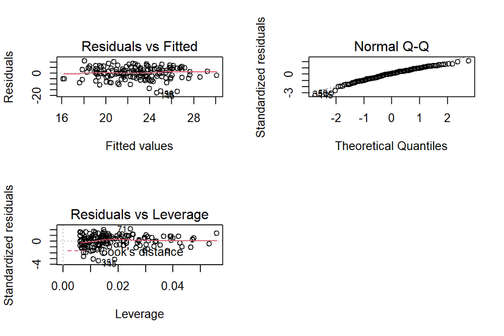

```r
par(mfrow = c(2,2))
plot(my_model2, which = c(1,2,5))
```

On the first plot we have the Residuals vs the Fitted values. This plot related the residuals (error) with the calculated values for the target variable. As we can observe in the plot, the variability of the results appears to remain constant regardless of the size of the fitted values and there is no clear pattern. It confirms the assumption that the size of the errors does not depend on the explanatory variable.

The second plot is the Normal qq-plot. This plot aid in checking for symmetry and normality of the error term in the regression. We see that most of the values fall on the identity line, but both the lower and upper tails of the data are skewed. this makes ud doubt the normality assumption of the errors in the model.

Lastly, we have the residuals vs leverage plot. The leverage plot helps us observe the influence of specific points in the data. We can see that there is no clear point with an increased impact over the model.

## Chapter 3: Logistic Regression

```r
date()
```

```
## [1] "Sun Dec 05 19:45:52 2021"
```

Here we go again…

Remember! Set your working directory and load your libraries.

```r
knitr::opts_knit$set(root.dir ="C:/Users/ramosgon/OneDrive - University of Helsinki/Courses/OpenDataScience/IODS-project/Data")

library(tidyverse)
library(ggplot2)
library(GGally)
library(ggpubr)
library(boot)
```

We read the data.

```r
pormath <- read.csv("pormath.csv", header = T, sep = ",")
```

The data comes from P. Cortez and A. Silva. Using Data Mining to Predict Secondary School Student Performance. In A. Brito and J. Teixeira Eds., Proceedings of 5th FUture BUsiness TEChnology Conference (FUBUTEC 2008) pp. 5-12, Porto, Portugal, April, 2008, EUROSIS, ISBN 978-9077381-39-7. The data explores the attributes of student lives and their effect on their academic performance in math and Portuguese classes. For more information on the data set, visit this [link](https://archive.ics.uci.edu/ml/datasets/Student+Performance).

For this analysis, we sill be focusing on the alcohol use of the students and the effect that various attributes might have on it.

We first explore the dimensions and structure.

```r
dim(pormath)
```

```
## [1] 370  50
```

```r
str(pormath)
```

```
## 'data.frame':    370 obs. of  50 variables:
##  $ school    : chr  "GP" "GP" "GP" "GP" ...
##  $ sex       : chr  "F" "F" "F" "F" ...
##  $ age       : int  18 17 15 15 16 16 16 17 15 15 ...
##  $ address   : chr  "U" "U" "U" "U" ...
##  $ famsize   : chr  "GT3" "GT3" "LE3" "GT3" ...
##  $ Pstatus   : chr  "A" "T" "T" "T" ...
##  $ Medu      : int  4 1 1 4 3 4 2 4 3 3 ...
##  $ Fedu      : int  4 1 1 2 3 3 2 4 2 4 ...
##  $ Mjob      : chr  "at_home" "at_home" "at_home" "health" ...
##  $ Fjob      : chr  "teacher" "other" "other" "services" ...
##  $ reason    : chr  "course" "course" "other" "home" ...
##  $ guardian  : chr  "mother" "father" "mother" "mother" ...
##  $ traveltime: int  2 1 1 1 1 1 1 2 1 1 ...
##  $ studytime : int  2 2 2 3 2 2 2 2 2 2 ...
```

[output cut: 36 more lines]

Since we are exploring the alcohol use, we will select the variables **high_use** and **alc_use**. The variable **high_use** marks students that consume alcohol on a frequency above 2 (numeric: from 1 - very low to 5 - very high) during the whole week while **alc_use** actual value (numeric: from 1 - very low to 5 - very high). Once we have our target variables, we select the effect variables that we wish to study. I am interested in finding out if **age**, **health**, or the family situation affect the alcohol consumption. Therefore, I will select **age** (numeric: from 15 to 22), **health** (numeric: from 1 - very bad to 5 - very good), **famrel** (numeric: from 1 - very bad to 5 - excellent), and **famsup** (binary: yes or no). Additionally, it is always interesting to take a look at the influence of gender, so I will be including **sex** (binary: ‘F’ - female or ‘M’ - male).

My hypothesis are:

- Due to the young **age** of the students, health will not show a significant relationship with **high_use**.
- Both **famrel** and **famsup** will have an effect in alcohol consumption. I expect that the better the family situation, the least consumption.
- **Age** will have a strong effect over **high_use**, simply due to acquisitive power and opportunity.

The three formats for the data shown below will allow us to create different types of graphs as it will be seen in the rest of the report.

```r
## Select the columns as they are
pormath_subset <- pormath %>%
  select(sex, high_use, alc_use, age, health, famrel, famsup)

## Turn sex, health, famrel, and famsup into factors
pormath_subset_fct <- pormath %>%
  select(sex, high_use, alc_use, age, health, famrel, famsup) %>%
  mutate(across(c(sex, health, famrel, famsup), factor))

## Turn health, famrel, and famsup into numeric values
pormath_subset_nmr <- pormath_subset_fct %>%
  mutate(across(c(health, famrel, famsup), as.numeric))
```

As a first look, we can explore our variables numerically. We can do this both as numeric variables:

```r
pormath_subset_nmr %>%
  summary
```

```
##  sex      high_use          alc_use           age            health
##  F:195   Mode :logical   Min.   :1.000   Min.   :15.00   Min.   :1.000
##  M:175   FALSE:259       1st Qu.:1.000   1st Qu.:16.00   1st Qu.:3.000
##          TRUE :111       Median :1.500   Median :17.00   Median :4.000
##                          Mean   :1.889   Mean   :16.58   Mean   :3.562
##                          3rd Qu.:2.500   3rd Qu.:17.00   3rd Qu.:5.000
##                          Max.   :5.000   Max.   :22.00   Max.   :5.000
##      famrel          famsup
##  Min.   :1.000   Min.   :1.000
##  1st Qu.:4.000   1st Qu.:1.000
##  Median :4.000   Median :2.000
##  Mean   :3.935   Mean   :1.624
##  3rd Qu.:5.000   3rd Qu.:2.000
##  Max.   :5.000   Max.   :2.000
```

or as factors and their frequency:

```r
pormath_subset_fct %>%
  summary
```

```
##  sex      high_use          alc_use           age        health  famrel
##  F:195   Mode :logical   Min.   :1.000   Min.   :15.00   1: 46   1:  8
##  M:175   FALSE:259       1st Qu.:1.000   1st Qu.:16.00   2: 42   2: 18
##          TRUE :111       Median :1.500   Median :17.00   3: 80   3: 64
##                          Mean   :1.889   Mean   :16.58   4: 62   4:180
##                          3rd Qu.:2.500   3rd Qu.:17.00   5:140   5:100
##                          Max.   :5.000   Max.   :22.00
##  famsup
##  no :139
##  yes:231
##
##
##
##
```

We can observe the following:

- The number of male and females is quite similar.
- More than twice as much students do not have **high use** of alcohol compared to those who do.
- 75% of the students have a 4 or 5 **family relationship**
- Almost twice as much students have **family support** compared to those who don’t.

Now we look at the graphical representation separated by **high_use**:

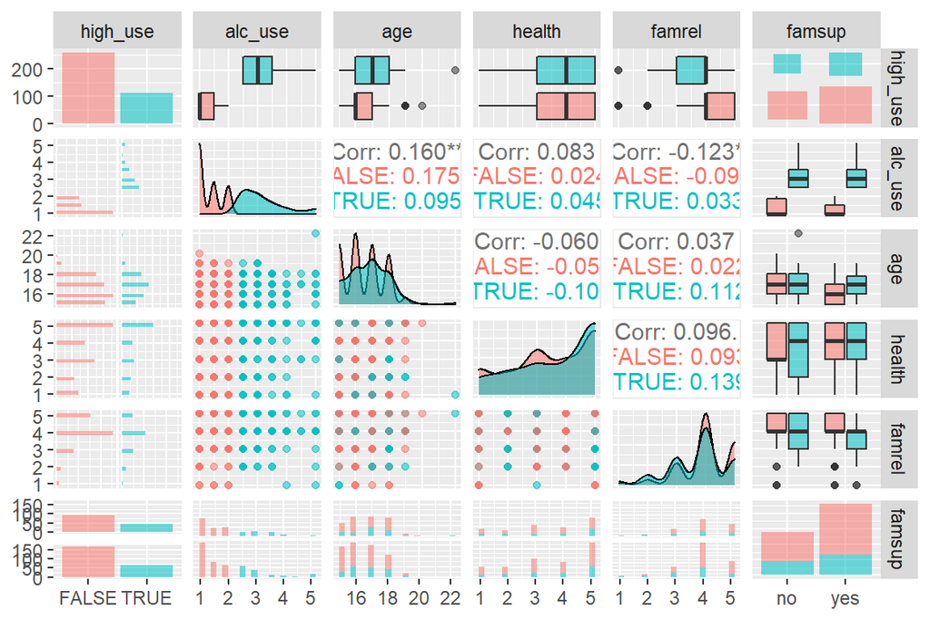

```r
pormath_subset %>%
  select(-sex) %>% # remove sex
  ggpairs(mapping = aes(col = high_use, alpha = 0.3),
          lower = list(combo = wrap("facethist", bins = 20)))
```

and **sex**:

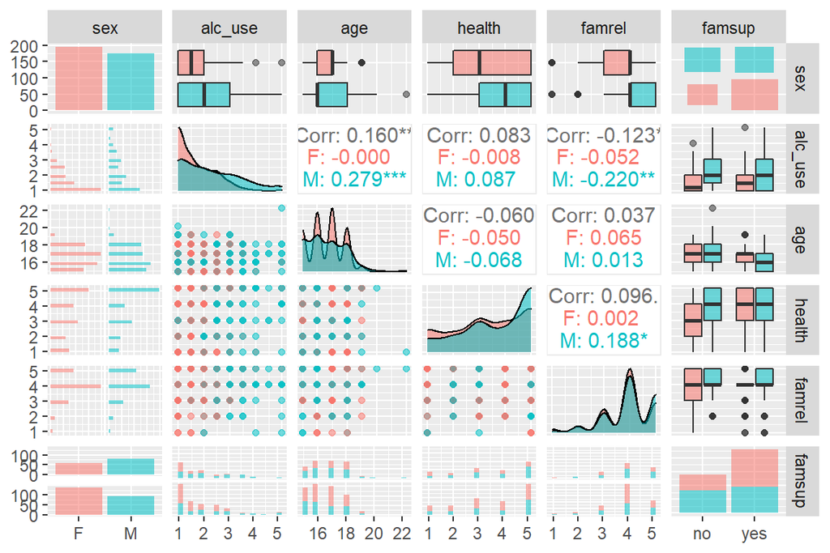

```r
pormath_subset %>%
  select(-high_use) %>% # remove high_use
  ggpairs(mapping = aes(col = sex, alpha = 0.3),
          lower = list(combo = wrap("facethist", bins = 20)))
```

Immediately we can notice that:

- **alc_use** has a strong correlation to **age** and **famrel** but mostly on male students.
- **health** has a strong correlation **famrel** but only on male students.

We can now look at the means and std deviations of the data by cross-tabulation:

```r
pormath_subset_nmr %>%
  group_by(high_use, sex) %>%
  summarise(
    AvgAge = mean(age),
    sdAge = sd(age),
    AvgHealth = mean(health),
    sdHealth= sd(health),
    AvgFamRel = mean(famrel),
    sdFamRel = sd(famrel),
    AvgFamSup = mean(famsup),
    sdFamSup = sd(famsup))
```

```
## # A tibble: 4 x 10
## # Groups:   high_use [2]
##   high_use sex   AvgAge sdAge AvgHealth sdHealth AvgFamRel sdFamRel AvgFamSup
##   <lgl>    <fct>  <dbl> <dbl>     <dbl>    <dbl>     <dbl>    <dbl>     <dbl>
## 1 FALSE    F       16.6  1.09      3.37     1.40      3.92    0.926      1.69
## 2 FALSE    M       16.3  1.24      3.67     1.41      4.13    0.833      1.55
## 3 TRUE     F       16.5  1.12      3.39     1.55      3.73    0.837      1.73
## 4 TRUE     M       16.9  1.23      3.93     1.28      3.79    0.991      1.51
## # ... with 1 more variable: sdFamSup <dbl>
```

But this is hard to read, so let us show it graphically. In the following graph we have the average values of each variable with their std error bars.

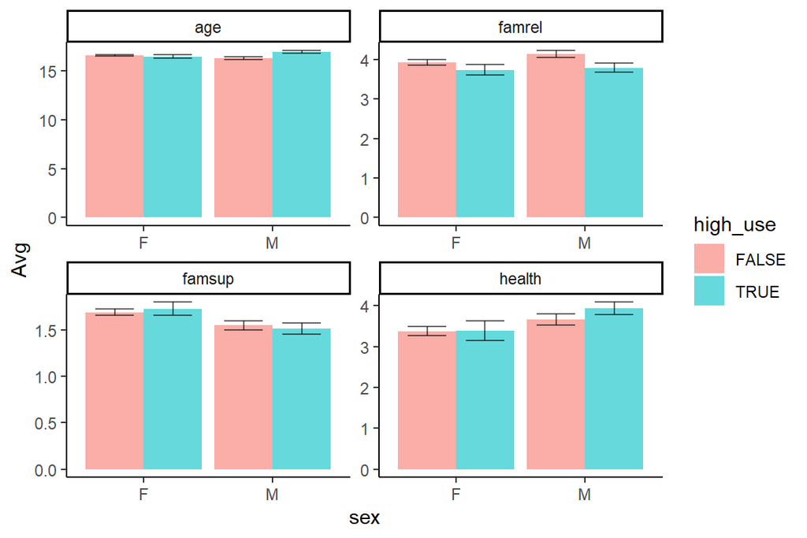

```r
pormath_subset_nmr %>%
  pivot_longer(cols = alc_use:famsup, names_to = "Attribute") %>%
  group_by(high_use, sex, Attribute) %>%
  summarise(Avg = mean(value),
            se = sd(value)/sqrt(length(value))) %>%
  filter(Attribute != "alc_use") %>%
  ggplot(aes(x = sex, y = Avg, fill = high_use)) +
  geom_bar(position = position_dodge(),
           stat = "identity",
           alpha = 0.6) +
  geom_errorbar(aes(x = sex, ymin = Avg-se, ymax = Avg+se),
                position = position_dodge(width = 0.9),
                width = 0.6,
                alpha = 0.6)+
  facet_wrap("Attribute", scales = "free") +
  theme_classic()
```

As expected, **high_use** presents difference in means larger than standard error in **age** and **famrel** but mostly on male students. As well, **health** shows some difference in the means **famrel** but only on male students and less than the standard error.

Now we look at box plots of each variable to confirm the data distribution.

First, **age**:

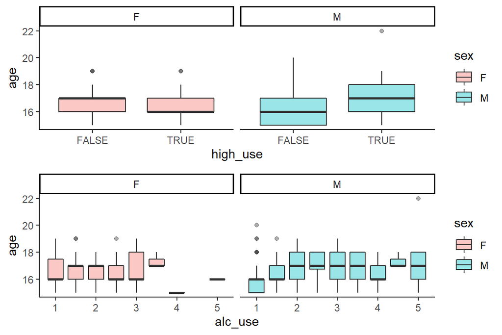

```r
g1 <- pormath_subset_nmr %>%
  ggplot(aes(x = high_use, y = age, fill = sex)) +
  geom_boxplot(alpha = 0.4) +
  facet_wrap("sex") +
  theme_classic()

g2 <- pormath_subset_nmr %>%
  ggplot(aes(x = alc_use, y = age, group = alc_use, fill = sex)) +
  geom_boxplot(alpha = 0.4) +
  facet_wrap("sex") +
  theme_classic()

ggarrange(g1, g2, ncol = 1)
```

On male particularly, there seems to be an increase in **alc_use** as **age** increases.

Then, **health**:

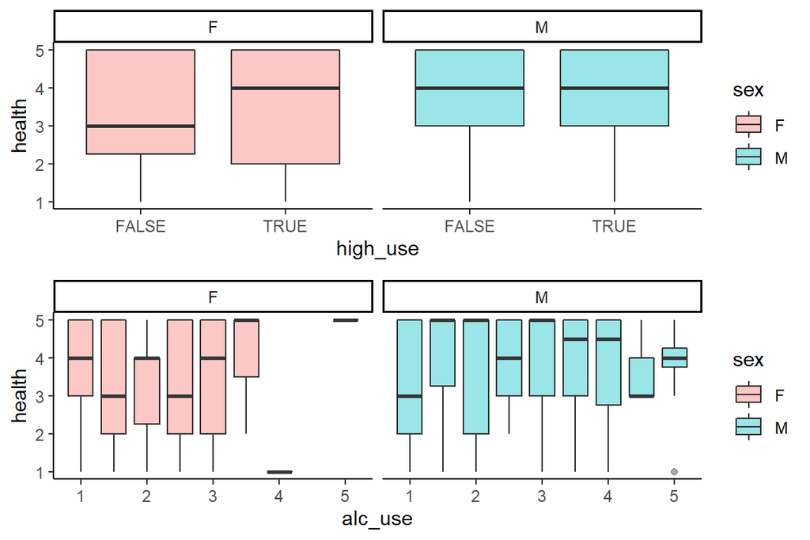

```r
g1 <- pormath_subset_nmr %>%
  ggplot(aes(x = high_use, y = health, fill = sex)) +
  geom_boxplot(alpha = 0.4) +
  facet_wrap("sex") +
  theme_classic()

g2 <- pormath_subset_nmr %>%
  ggplot(aes(x = alc_use, y = health, group = alc_use, fill = sex)) +
  geom_boxplot(alpha = 0.4) +
  facet_wrap("sex") +
  theme_classic()

ggarrange(g1, g2, ncol = 1)
```

No clear pattern is vissible.

Now, **famrel**:

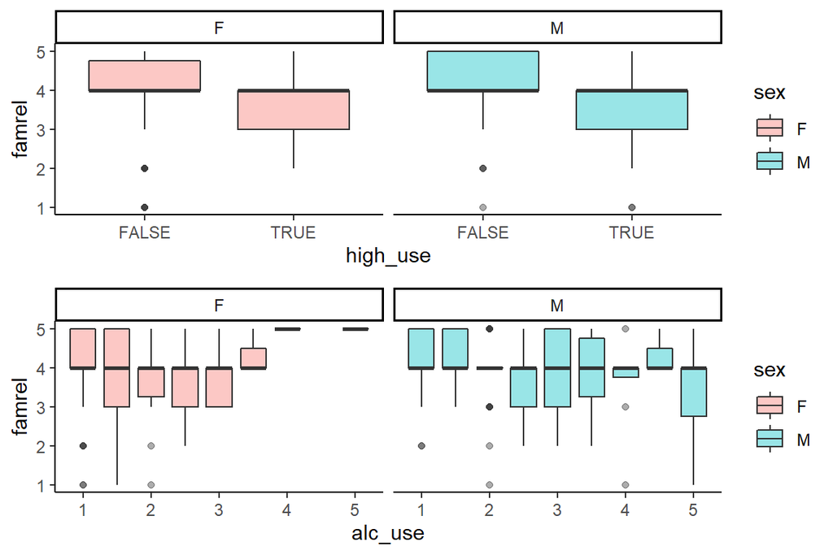

```r
g1 <- pormath_subset_nmr %>%
  ggplot(aes(x = high_use, y = famrel, fill = sex)) +
  geom_boxplot(alpha = 0.4) +
  facet_wrap("sex") +
  theme_classic()

g2 <- pormath_subset_nmr %>%
  ggplot(aes(x = alc_use, y = famrel, group = alc_use, fill = sex)) +
  geom_boxplot(alpha = 0.4) +
  facet_wrap("sex") +
  theme_classic()

ggarrange(g1, g2, ncol = 1)
```

I looks like students with **high_use** tend to have lower **famrel**.

**famsup** is a bit tricky, since it is a factor variable. Therefore we will use frequency and mean plots instead of box plots.

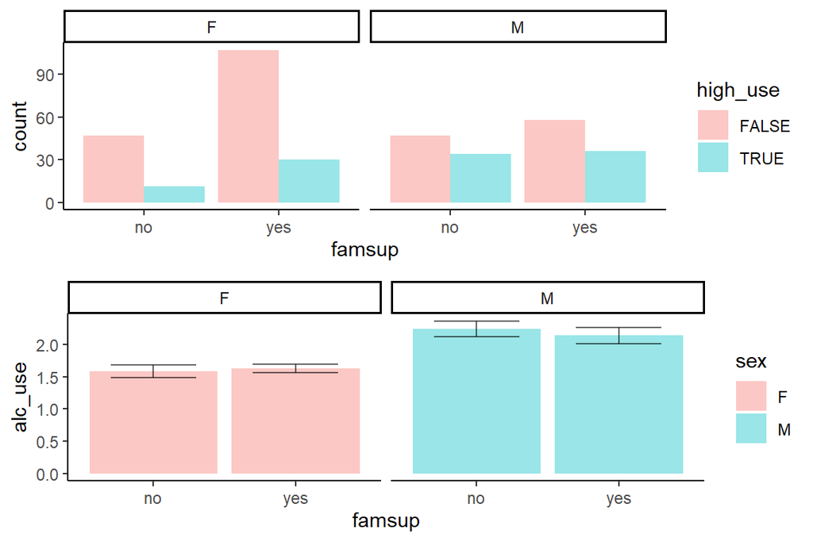

```r
g1 <- pormath_subset_fct %>%
  group_by(sex, famsup, high_use) %>%
  summarise(count = n()) %>%
  ggplot(aes(x = famsup, y = count, fill = high_use )) +
    geom_bar(position = "dodge",stat = "identity",alpha = 0.4) +
    facet_wrap("sex") +
    theme_classic()
g2 <- pormath_subset_fct %>%
  group_by(sex, famsup) %>%
  summarise( se = sd(alc_use)/sqrt(length(alc_use)),
             alc_use = mean(alc_use)) %>%
  ggplot(aes(x = famsup, y = alc_use, fill = sex)) +
  geom_bar(position = "dodge",stat = "identity",alpha = 0.4) +
  geom_errorbar(aes(x = famsup, ymin = alc_use-se, ymax = alc_use+se),
                position = position_dodge(width = 0.9),
                width = 0.6,
                alpha = 0.6) +
  facet_wrap("sex") +
  theme_classic()
ggarrange(g1, g2, ncol = 1)
```

**alc_use** does not seem to significantly change based on the **famsup**.

Lastly, I wanted to look at their average academic performance,which is depicted in the **G3** final grade (numeric: from 0 to 20, output target):

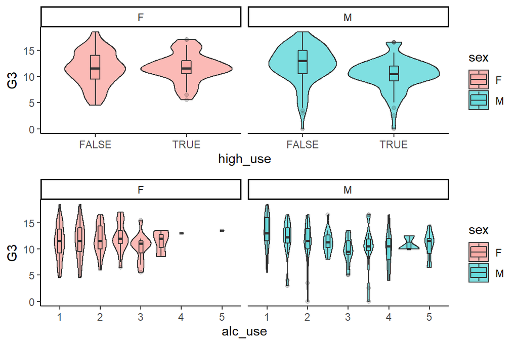

```r
g1 <- pormath %>%
  ggplot(aes(x = high_use, y = G3, fill = sex)) +
  geom_violin(width = 1, alpha = 0.5) +
  geom_boxplot(position = position_dodge(width =1),
               width = 0.1,
               alpha = 0.2) +
  facet_wrap("sex") +
  theme_classic()

g2 <- pormath %>%
  ggplot(aes(x = alc_use, y = G3, group = alc_use, fill = sex)) +
  geom_violin( width = 0.5, alpha = 0.5) +
  geom_boxplot( width = 0.1, alpha = 0.2) +
  facet_wrap("sex") +
  theme_classic()

ggarrange(g1, g2, ncol = 1)
```

While there is no significant change in the means, note how the variation in the **final grade** is much less as the **alc_use** and **high_use** increase. This means that the performance of those students that consume less alcohol has a wider distribution.

But, let us focus on building our model. We start by including the four variables of interest into the logistic regression model and looking at the ANOVA presented by the *summary()* function.

```r
model1 <- glm(high_use ~ age + health + famrel + famsup,
              data = pormath_subset,
              family = "binomial")

summary(model1)
```

```
##
## Call:
## glm(formula = high_use ~ age + health + famrel + famsup, family = "binomial",
##     data = pormath_subset)
##
## Deviance Residuals:
##     Min       1Q   Median       3Q      Max
## -1.4952  -0.8754  -0.7331   1.3372   2.0207
##
## Coefficients:
##             Estimate Std. Error z value Pr(>|z|)
## (Intercept) -3.65006    1.75593  -2.079   0.0376 *
## age          0.21535    0.09932   2.168   0.0301 *
## health       0.16502    0.08600   1.919   0.0550 .
## famrel      -0.32958    0.12617  -2.612   0.0090 **
## famsupyes   -0.14944    0.23926  -0.625   0.5322
## ---
## Signif. codes:  0 '***' 0.001 '**' 0.01 '*' 0.05 '.' 0.1 ' ' 1
##
## (Dispersion parameter for binomial family taken to be 1)
##
##     Null deviance: 452.04  on 369  degrees of freedom
## Residual deviance: 437.98  on 365  degrees of freedom
## AIC: 447.98
##
## Number of Fisher Scoring iterations: 4
```

**famsup** is a categorical variable, so the tests are performed a bit differently. Here, the Wald test is performed to test whether the difference between the coefficient of the reference (*no*) and the level (*yes*) is different from zero. Therefore, we know that there is no significant difference between this levels. To confirm if the whole variable isn’t significant, we remove the intercept.

```r
model2 <- glm(high_use ~ age + health + famrel + famsup - 1,
              data = pormath_subset,
              family = "binomial")

summary(model2)
```

```
##
## Call:
## glm(formula = high_use ~ age + health + famrel + famsup - 1,
##     family = "binomial", data = pormath_subset)
##
## Deviance Residuals:
##     Min       1Q   Median       3Q      Max
## -1.4952  -0.8754  -0.7331   1.3372   2.0207
##
## Coefficients:
##           Estimate Std. Error z value Pr(>|z|)
## age        0.21535    0.09932   2.168   0.0301 *
## health     0.16502    0.08600   1.919   0.0550 .
## famrel    -0.32958    0.12617  -2.612   0.0090 **
## famsupno  -3.65006    1.75593  -2.079   0.0376 *
## famsupyes -3.79950    1.72571  -2.202   0.0277 *
## ---
## Signif. codes:  0 '***' 0.001 '**' 0.01 '*' 0.05 '.' 0.1 ' ' 1
##
## (Dispersion parameter for binomial family taken to be 1)
##
##     Null deviance: 512.93  on 370  degrees of freedom
## Residual deviance: 437.98  on 365  degrees of freedom
## AIC: 447.98
##
## Number of Fisher Scoring iterations: 4
```

By removing the intercept, we are now testing if each coefficient of the categorical variable is different from zero. We see that the individual coefficients are now considered significant.

To resolve this contradiction, we can create a third model that does not contain the variable **famsup** and compare it to our first model using a likelihood ratio test. This will tell us the probability of all coefficients from **famsup** being zero.

```r
model3 <- glm(high_use ~ age + health + famrel,
              data = pormath_subset,
              family = "binomial")

summary(model3)
```

```
##
## Call:
## glm(formula = high_use ~ age + health + famrel, family = "binomial",
##     data = pormath_subset)
##
## Deviance Residuals:
##     Min       1Q   Median       3Q      Max
## -1.4559  -0.8625  -0.7425   1.3298   2.0631
##
## Coefficients:
##             Estimate Std. Error z value Pr(>|z|)
## (Intercept) -3.86577    1.72440  -2.242  0.02497 *
## age          0.22295    0.09865   2.260  0.02382 *
## health       0.16310    0.08593   1.898  0.05770 .
## famrel      -0.32859    0.12608  -2.606  0.00916 **
## ---
## Signif. codes:  0 '***' 0.001 '**' 0.01 '*' 0.05 '.' 0.1 ' ' 1
##
## (Dispersion parameter for binomial family taken to be 1)
##
##     Null deviance: 452.04  on 369  degrees of freedom
## Residual deviance: 438.37  on 366  degrees of freedom
## AIC: 446.37
##
## Number of Fisher Scoring iterations: 4
```

```r
anova(model1, model3, test = "LRT")
```

```
## Analysis of Deviance Table
##
## Model 1: high_use ~ age + health + famrel + famsup
## Model 2: high_use ~ age + health + famrel
##   Resid. Df Resid. Dev Df Deviance Pr(>Chi)
## 1       365     437.98
## 2       366     438.37 -1  -0.3887    0.533
```

We see the high Pr(>Chi) tells us that the variable should not remain in the model.

Now we can also see that **health** is not significant even though it is quite close. Therefore we will try removing it.

```r
model4 <- glm(high_use ~ age + famrel,
              data = pormath_subset,
              family = "binomial")

summary(model4)
```

```
##
## Call:
## glm(formula = high_use ~ age + famrel, family = "binomial", data = pormath_subset)
##
## Deviance Residuals:
##     Min       1Q   Median       3Q      Max
## -1.3086  -0.8605  -0.7384   1.3540   1.8530
##
## Coefficients:
##             Estimate Std. Error z value Pr(>|z|)
## (Intercept) -3.14909    1.66508  -1.891   0.0586 .
## age          0.20841    0.09761   2.135   0.0328 *
## famrel      -0.29917    0.12361  -2.420   0.0155 *
## ---
## Signif. codes:  0 '***' 0.001 '**' 0.01 '*' 0.05 '.' 0.1 ' ' 1
##
## (Dispersion parameter for binomial family taken to be 1)
##
##     Null deviance: 452.04  on 369  degrees of freedom
## Residual deviance: 442.08  on 367  degrees of freedom
## AIC: 448.08
##
## Number of Fisher Scoring iterations: 4
```

This caused the intercept to loose significance, but the remaining variables are marked as significant. Regardless, after running the predictive and cross-validation analysis, model 3 outperformed model 4. Therefore, I consider it to be the best available model with these variables.

So regarding my hypothesis:

- **FALSE** Even though **health** did not show a significant relationship with **high_use**, its inclusion in the model improved its performance.
- **PARTLY TRUE** Only **famrel** and not **famsup** had an effect in alcohol consumption.
- **TRUE** **Age** had a significant effect over **high_use**.

So let’s look at the odds ratios with their CI’s.

```r
model <- model3

OR <- model %>%
  coef %>%
  exp

CI <- model %>%
  confint %>%
  exp
m_OR <- cbind(OR, CI)
m_OR
```

```
##                     OR        2.5 %    97.5 %
## (Intercept) 0.02094671 0.0006882756 0.6060803
## age         1.24976103 1.0307101817 1.5191667
## health      1.17715618 0.9972312442 1.3977846
## famrel      0.71994050 0.5607948332 0.9210363
```

A 2X2 cross tabulation can give us a better idea of the predictive power of the model:

```r
probs <- predict(model, type = "response") # Predict probability responses based on the variables

pormath_predict <- pormath_subset %>%
  mutate(probability = probs) %>% # add them to our data.frame
  mutate(prediction = probability > 0.5) # Compare those probabilities to our significance cutoff to identify the logical value

# Plot the 2X2 cross tabulation of the predictions
table(high_use = pormath_predict$high_use,
      prediction = pormath_predict$prediction) %>%
  prop.table %>%
  addmargins()
```

```
##         prediction
## high_use      FALSE       TRUE        Sum
##    FALSE 0.68648649 0.01351351 0.70000000
##    TRUE  0.28648649 0.01351351 0.30000000
##    Sum   0.97297297 0.02702703 1.00000000
```

Around 70% of the values were predicted correctly. We can also see a graphical depiction:

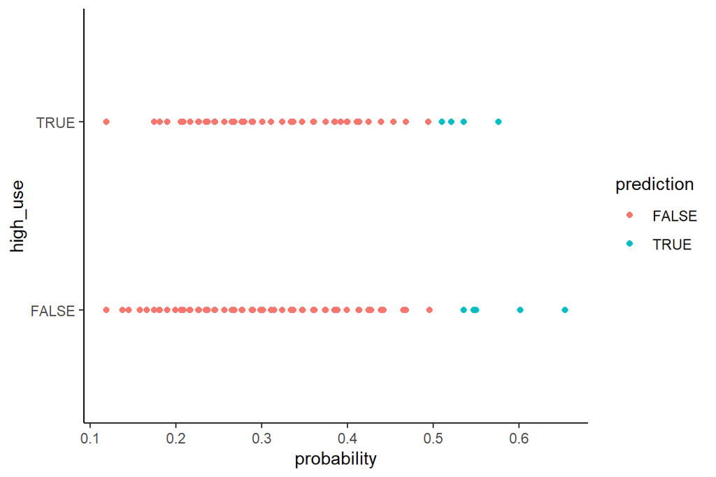

```r
pormath_predict %>%
  ggplot(aes(x = probability, y = high_use, col = prediction)) +
  geom_point() +
  theme_classic()
```

We also can compute the total proportion of inaccurately classified individuals or training error by using the following function:

```r
loss_func <- function(class, prob) {
  n_wrong <- abs(class - prob) > 0.5
  mean(n_wrong)
}
```

We can apply it to the data and compare its performance against a 10-fold cross-validation.

```r
te <- loss_func(class = pormath_predict$high_use, prob = pormath_predict$probability)

set.seed(1)
cv <- pormath_predict %>%
  cv.glm(cost = loss_func, glmfit = model, K = 10)

cat(paste("Training error: ", te, "\n10-fold CV: ", cv$delta[1]))
```

```
## Training error:  0.3
## 10-fold CV:  0.308108108108108
```

Using the variables I selected, I could not make the model have a better performance than that of the DataCamp exercise.

## Chapter 4: Clustering and classification

```r
date()
```

```
## [1] "Sun Dec 05 19:46:13 2021"
```

Here we go again…

Remember! Set your working directory and load your libraries.

```r
knitr::opts_knit$set(root.dir ="C:/Users/ramosgon/OneDrive - University of Helsinki/Courses/OpenDataScience/IODS-project/Data")

library(tidyverse)
library(ggplot2)
library(MASS)
library(corrplot)
library(GGally)
library(car)
```

We read the data.

```r
data("Boston")
```

“Housing Values in Suburbs of Boston” is a data set native to the MASS package in R. The data set includes various indicators for the different Boston suburbs. Further explanation on the variables can be found [here](https://stat.ethz.ch/R-manual/R-devel/library/MASS/html/Boston.html).

We first explore the dimensions and structure.

```r
dim(Boston)
```

```
## [1] 506  14
```

```r
str(Boston)
```

```
## 'data.frame':    506 obs. of  14 variables:
##  $ crim   : num  0.00632 0.02731 0.02729 0.03237 0.06905 ...
##  $ zn     : num  18 0 0 0 0 0 12.5 12.5 12.5 12.5 ...
##  $ indus  : num  2.31 7.07 7.07 2.18 2.18 2.18 7.87 7.87 7.87 7.87 ...
##  $ chas   : int  0 0 0 0 0 0 0 0 0 0 ...
##  $ nox    : num  0.538 0.469 0.469 0.458 0.458 0.458 0.524 0.524 0.524 0.524 ...
##  $ rm     : num  6.58 6.42 7.18 7 7.15 ...
##  $ age    : num  65.2 78.9 61.1 45.8 54.2 58.7 66.6 96.1 100 85.9 ...
##  $ dis    : num  4.09 4.97 4.97 6.06 6.06 ...
##  $ rad    : int  1 2 2 3 3 3 5 5 5 5 ...
##  $ tax    : num  296 242 242 222 222 222 311 311 311 311 ...
##  $ ptratio: num  15.3 17.8 17.8 18.7 18.7 18.7 15.2 15.2 15.2 15.2 ...
##  $ black  : num  397 397 393 395 397 ...
##  $ lstat  : num  4.98 9.14 4.03 2.94 5.33 ...
##  $ medv   : num  24 21.6 34.7 33.4 36.2 28.7 22.9 27.1 16.5 18.9 ...
```

The data set contains mostly numeric variables with the exception of **rad** (index of accessibility to radial highways) and **chas** (Charles River dummy variable (= 1 if tract bounds river; 0 otherwise)). They are a ranked factor and a logical variable respectively. Therefore we convert them and look at the results.

**Note:** Because of rad increased number of factor levels, we will keep as integer.

```r
Boston <- Boston %>%
  mutate(chas = as.logical(chas))

summary(Boston)
```

```
##       crim                zn             indus          chas
##  Min.   : 0.00632   Min.   :  0.00   Min.   : 0.46   Mode :logical
##  1st Qu.: 0.08205   1st Qu.:  0.00   1st Qu.: 5.19   FALSE:471
##  Median : 0.25651   Median :  0.00   Median : 9.69   TRUE :35
##  Mean   : 3.61352   Mean   : 11.36   Mean   :11.14
##  3rd Qu.: 3.67708   3rd Qu.: 12.50   3rd Qu.:18.10
##  Max.   :88.97620   Max.   :100.00   Max.   :27.74
##       nox               rm             age              dis
##  Min.   :0.3850   Min.   :3.561   Min.   :  2.90   Min.   : 1.130
##  1st Qu.:0.4490   1st Qu.:5.886   1st Qu.: 45.02   1st Qu.: 2.100
##  Median :0.5380   Median :6.208   Median : 77.50   Median : 3.207
##  Mean   :0.5547   Mean   :6.285   Mean   : 68.57   Mean   : 3.795
##  3rd Qu.:0.6240   3rd Qu.:6.623   3rd Qu.: 94.08   3rd Qu.: 5.188
##  Max.   :0.8710   Max.   :8.780   Max.   :100.00   Max.   :12.127
##       rad              tax           ptratio          black
##  Min.   : 1.000   Min.   :187.0   Min.   :12.60   Min.   :  0.32
##  1st Qu.: 4.000   1st Qu.:279.0   1st Qu.:17.40   1st Qu.:375.38
##  Median : 5.000   Median :330.0   Median :19.05   Median :391.44
##  Mean   : 9.549   Mean   :408.2   Mean   :18.46   Mean   :356.67
##  3rd Qu.:24.000   3rd Qu.:666.0   3rd Qu.:20.20   3rd Qu.:396.23
##  Max.   :24.000   Max.   :711.0   Max.   :22.00   Max.   :396.90
##      lstat            medv
##  Min.   : 1.73   Min.   : 5.00
##  1st Qu.: 6.95   1st Qu.:17.02
##  Median :11.36   Median :21.20
##  Mean   :12.65   Mean   :22.53
##  3rd Qu.:16.95   3rd Qu.:25.00
##  Max.   :37.97   Max.   :50.00
```

The past table provides a lot on information on quartile distribution of our variables, but I always rather look at the variables with boxplots or barplots:

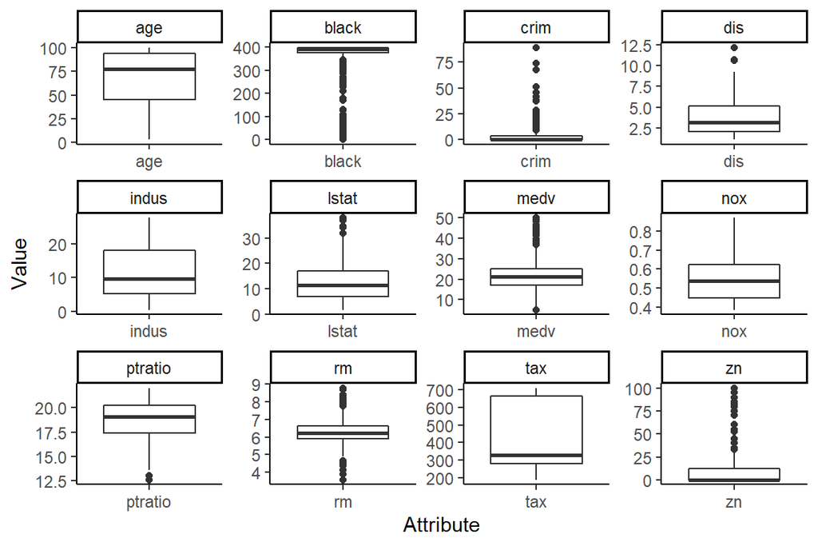

```r
Boston %>%
  pivot_longer(cols = c(1:14), names_to = "Attribute", values_to = "Value") %>%
  filter(!Attribute %in% c("chas","rad")) %>%
  ggplot(aes(x = Attribute, y = Value)) +
  geom_boxplot() +
  facet_wrap("Attribute", scales = "free") +
  theme_classic()
```

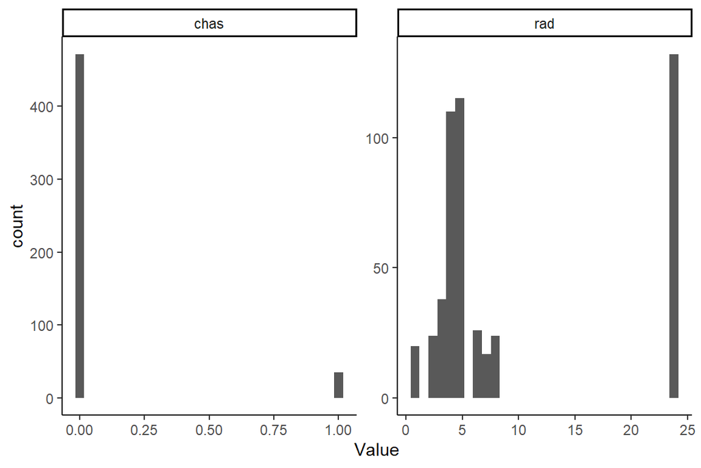

```r
Boston %>%
  pivot_longer(cols = c(1:14), names_to = "Attribute", values_to = "Value") %>%
  filter(Attribute %in% c("chas","rad")) %>%
  ggplot(aes(x = Value)) +
  geom_histogram() +
  facet_wrap("Attribute", scales = "free") +
  theme_classic()
```

We can conclude:

- 93% of towns do not have boundaries to the Charles River.
- Below 10 index of accessibility to radial highways, there seems to be a normal distribution that is disrupted by those with 24 index.
- 3rd quartile of cities only present up to 3.67 crimes per capita.
- Only the 1st quartile is under 375 of black population (see calculation [here](https://stat.ethz.ch/R-manual/R-devel/library/MASS/html/Boston.html)).

Additionally, we can look at the normality of the non-factorial distributions using the qqPlot.

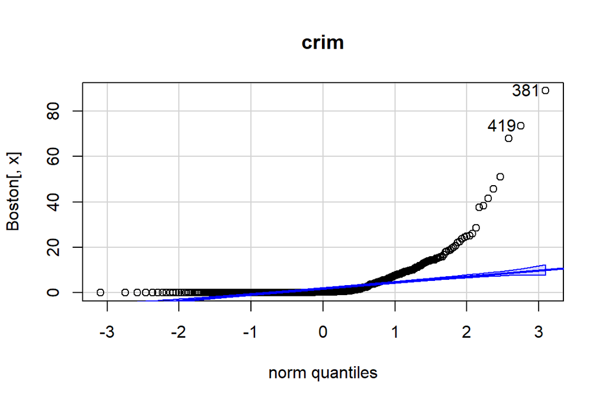

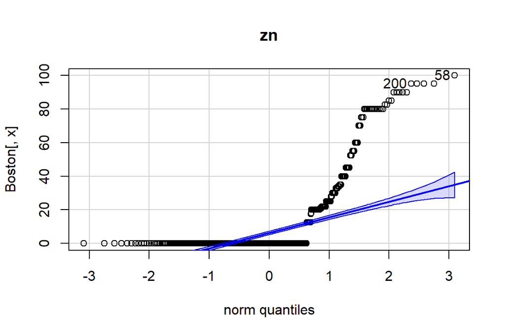

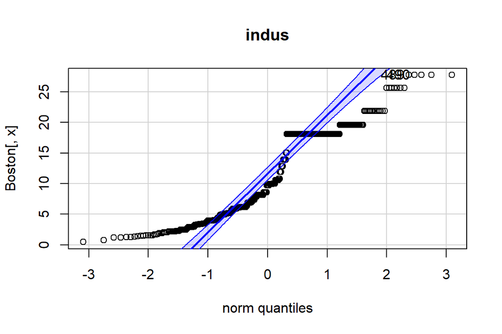

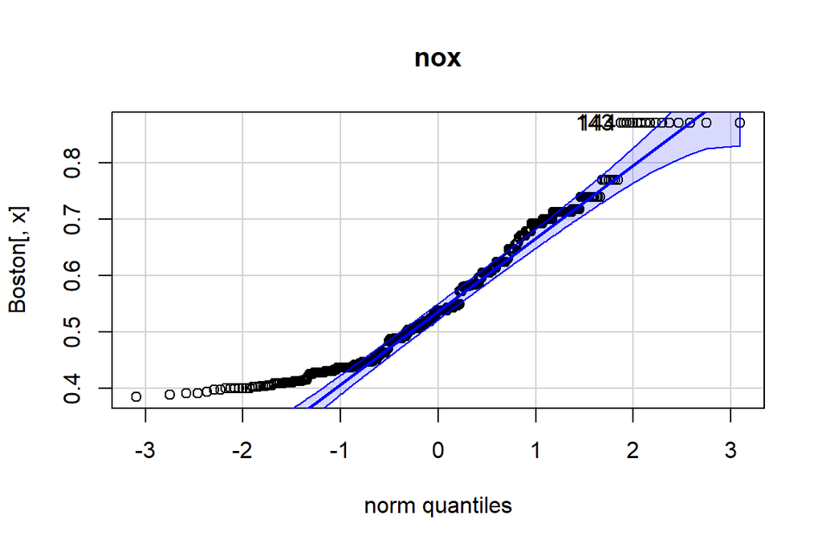

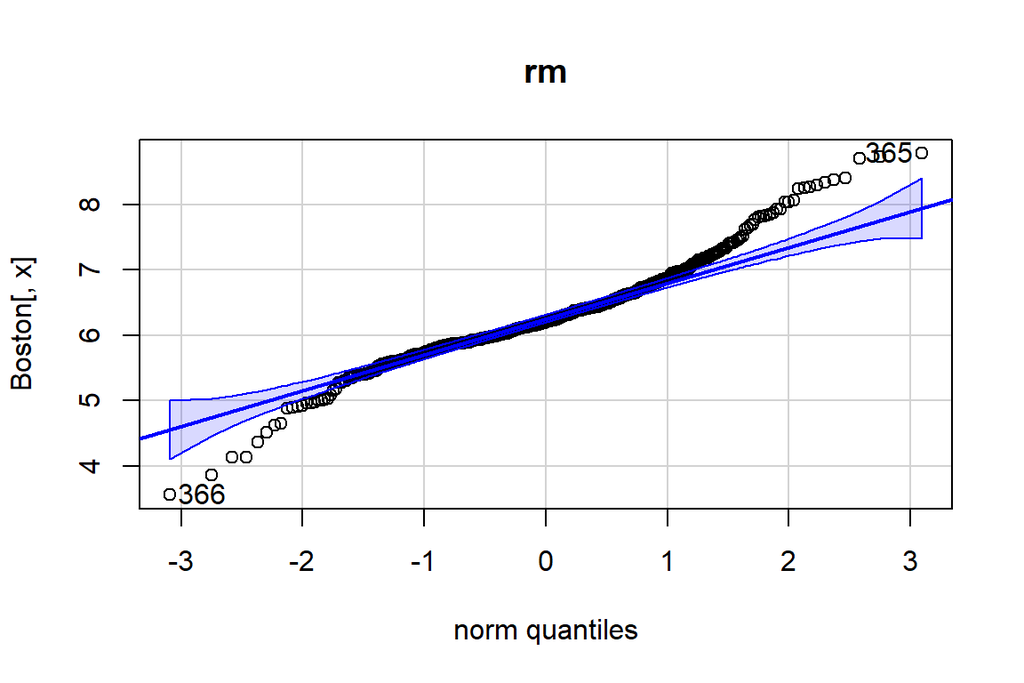

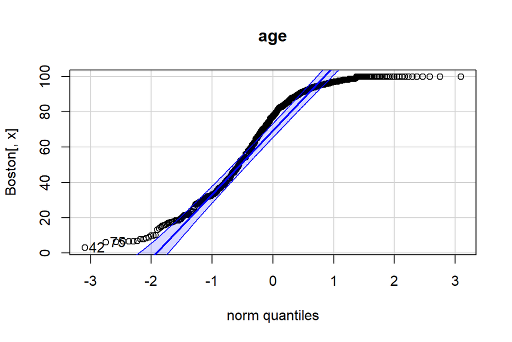

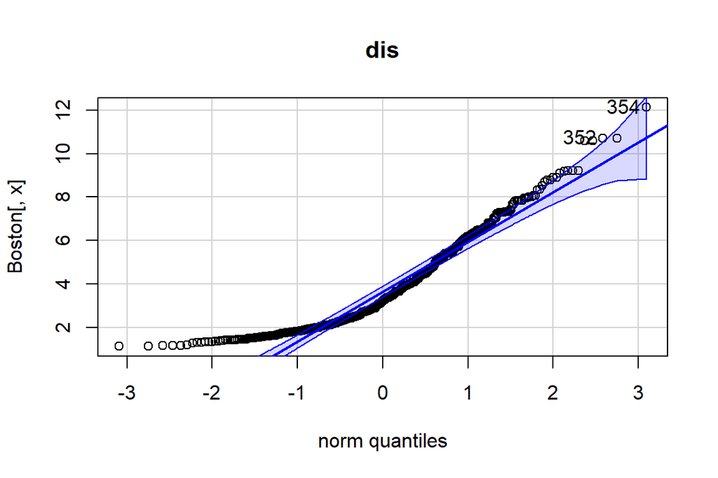

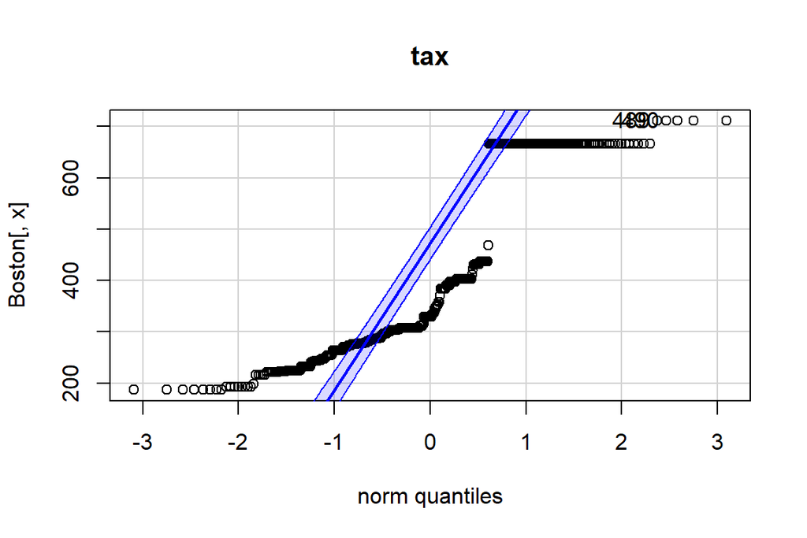

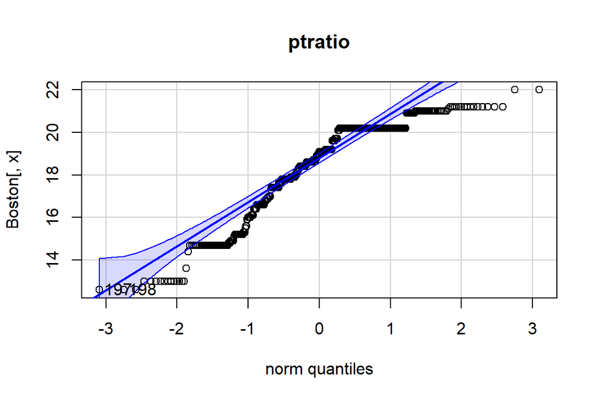

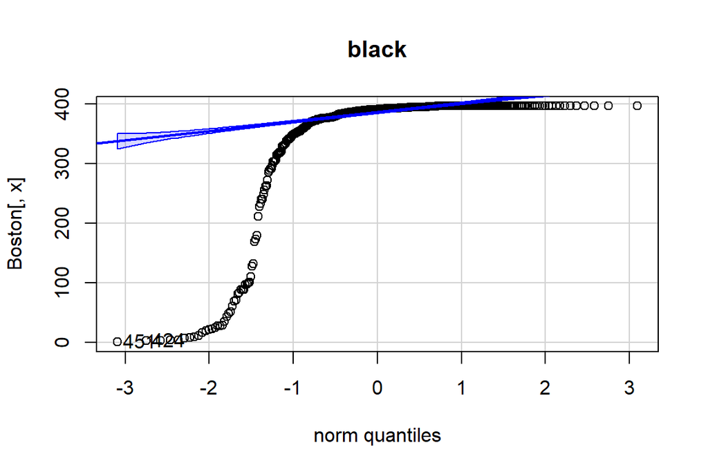

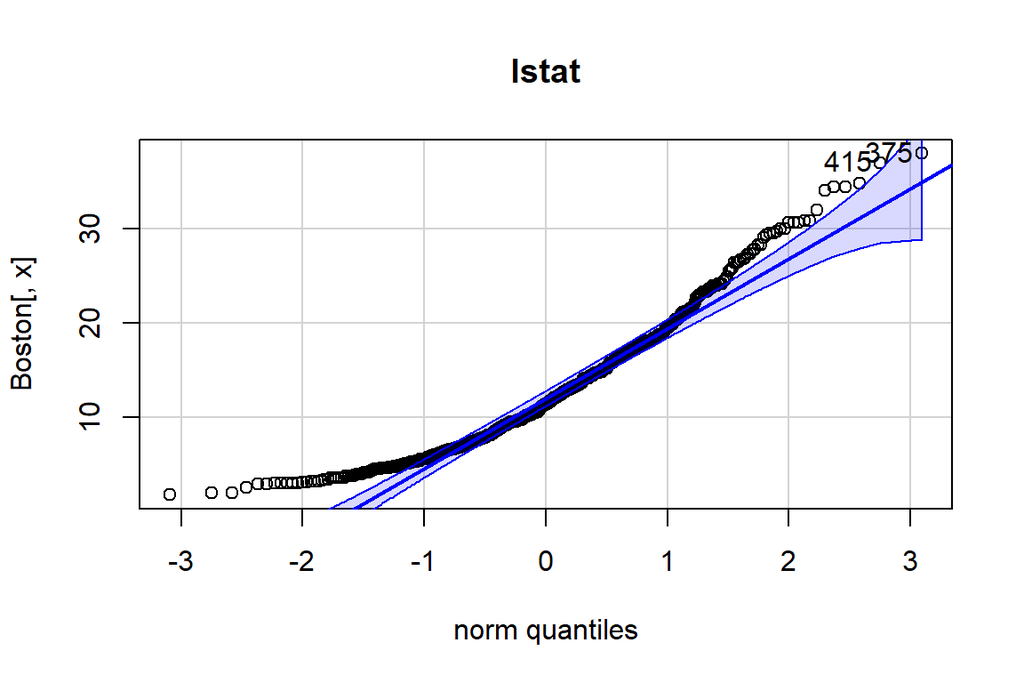

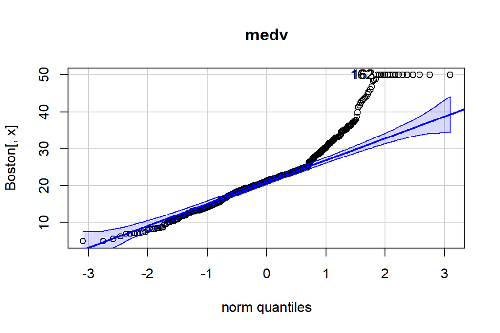

```
##      crim  zn indus nox  rm age dis tax ptratio black lstat medv
## [1,]  381  58   489 143 366  42 354 489     197   451   375  162
## [2,]  419 200   490 144 365  75 352 490     198   424   415  163
```

```r
colnames(Boston)[-c(4,9)] %>% sapply(function(x){
  qqPlot(Boston[,x], main = x)
})
```